# Homework 4

Ashley Sackpraseuth

10/4/2020

# Flight Data

## Loading libraries

```r
library(nycflights13)
library(tidyverse)
```

## Questions

1. Find if each flight number is used only once in a day. (Hint: You may need the any() function).

```r
#Make a separate dataframe containing only the flight, year, month, and day columns
flightnum <- select(flights, flight, year, month, day)

#Group by the year, month, day, (and flight). Count the number of times that flight number shows up that day.
flights_perday<- flightnum %>%
                 group_by(year, month, day, flight) %>%
                 count(flight)

print((flights_perday))
```

```
## # A tibble: 304,166 x 5
## # Groups:   year, month, day, flight [304,166]
##     year month   day flight     n
##    <int> <int> <int>  <int> <int>
##  1  2013     1     1      1     2
##  2  2013     1     1      3     2
##  3  2013     1     1      4     2
##  4  2013     1     1      6     1
##  5  2013     1     1      7     1
##  6  2013     1     1      8     1
##  7  2013     1     1      9     1
##  8  2013     1     1     11     3
##  9  2013     1     1     12     1
## 10  2013     1     1     15     2
## # ... with 304,156 more rows
```

It looks like flight numbers were used more than once on any given day. If we only want to see the flight numbers that were reused on the same day then

```r
flight_dups <- flightnum %>%
               count(year, month, day, flight) %>%
               filter(n > 1)

print(flight_dups)
```

```
## # A tibble: 29,768 x 5
##     year month   day flight     n
##    <int> <int> <int>  <int> <int>
##  1  2013     1     1      1     2
##  2  2013     1     1      3     2
##  3  2013     1     1      4     2
##  4  2013     1     1     11     3
##  5  2013     1     1     15     2
##  6  2013     1     1     21     2
##  7  2013     1     1     27     4
##  8  2013     1     1     31     2
##  9  2013     1     1     32     2
## 10  2013     1     1     35     2
## # ... with 29,758 more rows
```

2. Add the location of the origin and destination (i.e. the lat and lon) to flights. Retain only columns for the airport code, airport name, longitude, and latitude. Name the columns in a user-friendly manner.

```r
airport_loc <- airports %>%
  select(faa, latitude = lat, longitude = lon, name = name)

flights_loc <- flights %>%
              select(origin, dest) %>%
              left_join(
                airport_loc,
                by = c("origin" = "faa")
                ) %>%
              left_join(
                airport_loc,
                by = c("dest" = "faa"),
                suffix = c("_origin", "_dest")
              )

flights_loc
```

```
## # A tibble: 336,776 x 8
##    origin dest  latitude_origin longitude_origin name_origin latitude_dest
##    <chr>  <chr>           <dbl>            <dbl> <chr>               <dbl>
##  1 EWR    IAH              40.7            -74.2 Newark Lib~          30.0
##  2 LGA    IAH              40.8            -73.9 La Guardia           30.0
##  3 JFK    MIA              40.6            -73.8 John F Ken~          25.8
##  4 JFK    BQN              40.6            -73.8 John F Ken~          NA
##  5 LGA    ATL              40.8            -73.9 La Guardia           33.6
##  6 EWR    ORD              40.7            -74.2 Newark Lib~          42.0
##  7 EWR    FLL              40.7            -74.2 Newark Lib~          26.1
##  8 LGA    IAD              40.8            -73.9 La Guardia           38.9
##  9 JFK    MCO              40.6            -73.8 John F Ken~          28.4
## 10 LGA    ORD              40.8            -73.9 La Guardia           42.0
## # ... with 336,766 more rows, and 2 more variables: longitude_dest <dbl>,
## #   name_dest <chr>
```

3. Create appropriate numerical and/or graphical summaries to investigate how visibility condition makes it more likely to see a delay. Make sure to also investigate the flight delays with missing visibility values. (Hint: use left_join)

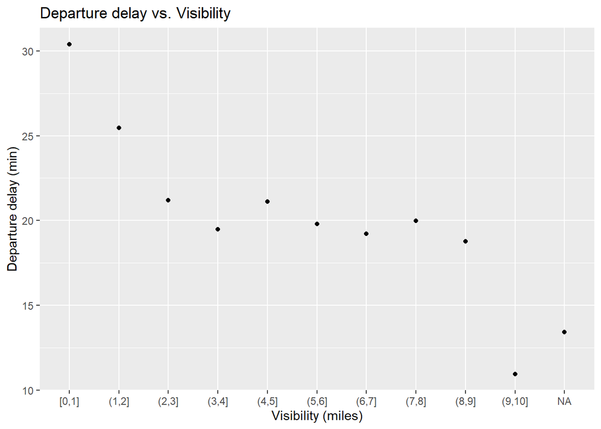

```r
#Known visibility values
#Departure delays
visibility_dep <- flights %>%
              left_join(weather) %>%
              mutate(visib_cat = cut_interval(visib, n = 10)) %>%
              group_by(visib_cat) %>%
              summarise(dep_delay = mean(dep_delay, na.rm = TRUE)) %>%
              ggplot(aes(x = visib_cat, y = dep_delay)) +
              geom_point() + ggtitle("Departure delay vs. Visibility") +
              xlab("Visibility (miles)") + ylab("Departure delay (min)")
visibility_dep
```

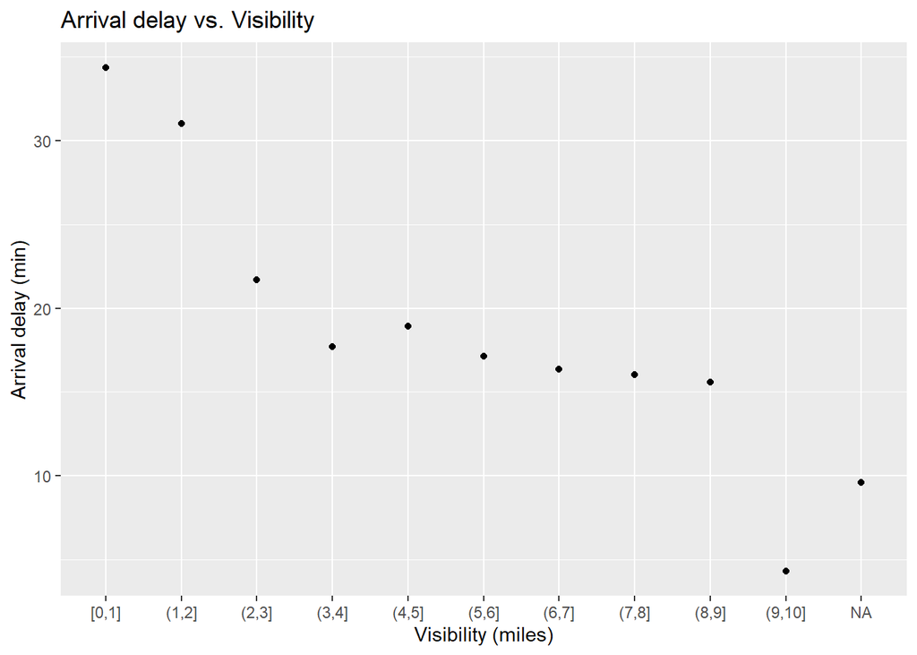

```r
#Arrival delays
visibility_arr <- flights %>%
                  left_join(weather) %>%
                  mutate(visib_cat = cut_interval(visib, n = 10)) %>%
                  group_by(visib_cat) %>%
                  summarise(arr_delay = mean(arr_delay, na.rm = TRUE)) %>%
                  ggplot(aes(x = visib_cat, y = arr_delay)) +
                  geom_point() + ggtitle("Arrival delay vs. Visibility") +
                  xlab("Visibility (miles)") + ylab("Arrival delay (min)")
visibility_arr
```

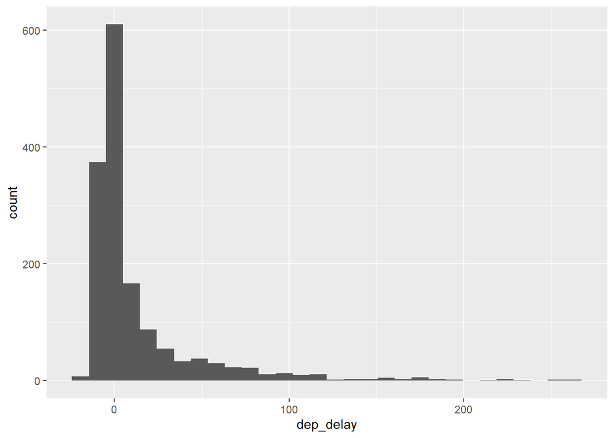

```r
#Missing visibility values
#Departure delays
visib_missing_dep <- flights %>%
                     left_join(weather) %>%
                     filter(is.na(visib)) %>%
                     ggplot(aes(x = dep_delay)) + geom_histogram()
visib_missing_dep
```

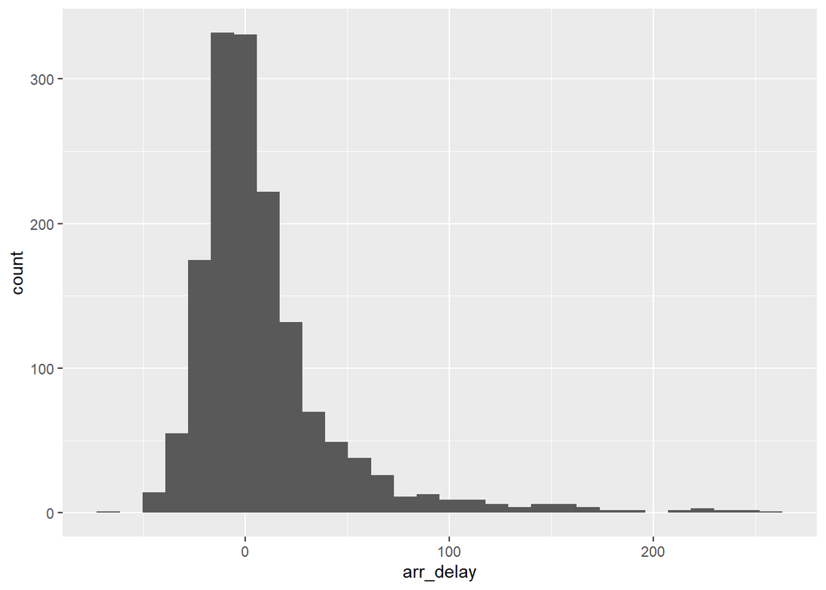

```r
#Arrival delays
visib_missing_arr <- flights %>%
                     left_join(weather) %>%
                     filter(is.na(visib)) %>%
                     ggplot(aes(x = arr_delay)) + geom_histogram()
visib_missing_arr
```

4. Which 3 destination airports have the most severe arrival delay? The severity of delay is defined as the proportion of arriving flights that have no less than 30 minutes arrival delay. Create a data frame containing their airport name, code, and the severity of delay.

```r
#Have to join with airport dataframe to include airport name
airport_name <- airports %>%
  select(faa, name = name)

severe_dest_delay <- flights %>%
                     select(dest, arr_delay) %>%
                     left_join(
                      airport_name,
                      by = c("dest" = "faa")
                     ) %>%
                     mutate(delay = ifelse(arr_delay < 30, "normal", "severe")) %>%
                     count(dest, name, delay) %>%
                     group_by(dest) %>%
                     mutate(prop = n / sum(n)) %>%
                     filter(delay == "severe") %>%
                     arrange(desc(prop), desc(n))

severe_dest_delay
```

```
## # A tibble: 102 x 5
## # Groups:   dest [102]
##    dest  name                   delay      n  prop
##    <chr> <chr>                  <chr>  <int> <dbl>
##  1 CAE   Columbia Metropolitan  severe    51 0.440
##  2 TUL   Tulsa Intl             severe   113 0.359
##  3 OKC   Will Rogers World      severe   123 0.355
##  4 JAC   Jackson Hole Airport   severe     8 0.32
##  5 TYS   Mc Ghee Tyson          severe   178 0.282
##  6 MSN   Dane Co Rgnl Truax Fld severe   152 0.266
##  7 SMF   Sacramento Intl        severe    73 0.257
##  8 CRW   Yeager                 severe    35 0.254
##  9 DSM   Des Moines Intl        severe   144 0.253
## 10 RIC   Richmond Intl          severe   619 0.252
## # ... with 92 more rows
```

The 3 destination airports with the most severe arrival delays are CAE (Columbia Metropolitan), TUL (Tulsa Intl), and OKC (Will Rogers World).

5. What happened on June 13 2013? Look at the delay severity by airport on that day, and then use Google to cross-reference with the weather.

```r
jun_13 <- flights %>%
          filter(year == 2013, month == 6, day == 13) %>%
          group_by(dest) %>%
          summarise(delay = mean(arr_delay, na.rm = TRUE)) %>%
          inner_join(airports, by = c("dest" = "faa")) %>%
          arrange(desc(delay))
jun_13
```

```
## # A tibble: 85 x 9
##    dest  delay name                   lat    lon   alt    tz dst   tzone
##    <chr> <dbl> <chr>                <dbl>  <dbl> <dbl> <dbl> <chr> <chr>
##  1 TYS    198  "Mc Ghee Tyson"       35.8  -84.0   981    -5 A     America/New_~
##  2 BUR    166  "Bob Hope"            34.2 -118.    778    -8 A     America/Los_~
##  3 BWI    161  "Baltimore Washingt~  39.2  -76.7   146    -5 A     America/New_~
##  4 BHM    158  "Birmingham Intl"     33.6  -86.8   644    -6 A     America/Chic~
##  5 MVY    155  "Martha\\\\'s Viney~  41.4  -70.6    67    -5 A     America/New_~
##  6 OAK    128  "Metropolitan Oakla~  37.7 -122.      9    -8 A     America/Los_~
##  7 CAK    124. "Akron Canton Regio~  40.9  -81.4  1228    -5 A     America/New_~
##  8 PHL    118  "Philadelphia Intl"   39.9  -75.2    36    -5 A     America/New_~
##  9 ORF    112. "Norfolk Intl"        36.9  -76.2    26    -5 A     America/New_~
## 10 JAX    109. "Jacksonville Intl"   30.5  -81.7    30    -5 A     America/New_~
## # ... with 75 more rows
```